# **Ο αλγόριθμος Πολυωνυμικής Παλινδρόμησης (Polynomial Regression)**

Στην άσκηση αυτή θα μελετήσετε τον αλγόριθμο *πολυωνυμικής παλινδρόμησης* (*polynomial regression*). Για την εκπαίδευση του μοντέλου θα χρησιμοποιήσετε τα δεδομένα του αρχείου *data2.csv*, το οποίο βρίσκεται ήδη φορτωμένο στο Notebook.

Στο Notebook αυτό περιλαμβάνονται εντολές για (α) τη φόρτωση των δεδομένων εκπαίδευσης που περιέχονται στο αρχείο *data2.csv*, (β) την εκπαίδευση ενός μοντέλου *linear regression* και την προσαρμογή του πάνω στα δεδομένα εκπαίδευσης, (γ) την εκπαίδευση ενός μοντέλου *polynomial regression* βαθμού *degree* και την προσαρμογή του πάνω στα δεδομένα εκπαίδευσης και (δ) την οπτικοποίηση των δεδομένων εκπαίδευσης, καθώς και των γραμμών απόφασης για τα δύο μοντέλα παλινδρόμησης. Για την εκπαίδευση των δύο μοντέλων παλινδρόμησης χρησιμοποιείται η βιβλιοθήκη *Scikit-Learn* της *Python*. Περισσότερες πληροφορίες για τον αλγόριθμο *polynomial regression* και τον κώδικα της άσκησης μπορούν να βρεθούν [εδώ](https://www.geeksforgeeks.org/python-implementation-of-polynomial-regression/).

Στην άσκηση αυτή, καλείστε να παρατηρήσετε τη μορφή και τις αλλαγές της γραμμής παλινδρόμησης για διαφορετικές τιμές της παραμέτρου *degree* βάσει των δεδομένων εκπαίδευσης που παρέχονται.

Αρχικά, θα εγκαταστήσετε και θα φορτώσετε τις απαραίτητες βιβλιοθήκες.

```python
import numpy as np
import matplotlib.pyplot as plt
import pandas as pd
from sklearn.preprocessing import PolynomialFeatures
from sklearn.linear_model import LinearRegression
```

Στη συνέχεια, θα φορτώσετε τα δεδομένα εκπαίδευσης που παρέχονται από το αρχείο *data2.csv*</i>.

```python
datas = pd.read_csv('data2.csv')
print(datas)
```

```
    sno  Temperature  Pressure
0     1            0    0.0002
1     2            5    0.0010
2     3           10    0.0017
3     4           15    0.0040
4     5           20    0.0200
5     6           25    0.0400
6     7           30    0.0100
7     8           35    0.0340
8     9           40    0.0500
9    10           45    0.0600
10   11           50    0.0700
11   12           55    0.0800
12   13           60    0.0900
13   14           65    0.1000
14   15           70    0.1100
```

Τώρα, θα δημιουργήσετε τις μεταβλητές εισόδου και εξόδου για τους αλγορίθμους μηχανικής μάθησης από τα δεδομένα εκπαίδευσης που παρέχονται.

```python
X = datas.iloc[:, 1:2].values
y = datas.iloc[:, 2].values

print("Input")

print(X)

print("Labels")

print(y)
```

```
Input
[[ 0]
 [ 5]
 [10]
 [15]
 [20]
 [25]
 [30]
 [35]
 [40]
 [45]
 [50]
 [55]
 [60]
 [65]
 [70]]
Labels
[0.0002 0.001  0.0017 0.004  0.02   0.04   0.01   0.034  0.05   0.06
 0.07   0.08   0.09   0.1    0.11  ]
```

Στη συνέχεια, θα εκπαιδεύσετε το μοντέλο *linear regression*, χρησιμοποιώντας τα παραπάνω δεδομένα εκπαίδευσης.

```python
lin = LinearRegression()
lin.fit(X, y)
```

```
LinearRegression(copy_X=True, fit_intercept=True, n_jobs=None, normalize=False)
```

### *Ερώτημα 1*

Να εκτελέσετε τα παρακάτω τμήματα κώδικα για τις τιμές της παραμέτρου *degree* {*2, 3, 4, 5, 8, 10, 12, 15*} και να καταγράψετε τα διαγράμματα που παρέχονται ως έξοδοι. Τι αλλαγές παρατηρείτε στη μορφή της γραμμής παλινδρόμησης για το μοντέλο *polynomial regression*, καθώς αυξάνεται η τιμή της παραμέτρου *degree*; Τι παρατηρείτε για τον απαιτούμενο χρόνο εκπαίδευσης του μοντέλου *polynomial regression*, καθώς αυξάνεται η τιμή της παραμέτρου *degree*;

#### *degree* = 2

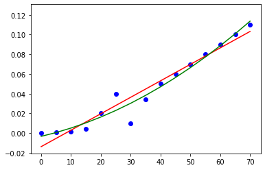

```python
poly = PolynomialFeatures(degree=2)
X_poly = poly.fit_transform(X)
poly.fit(X_poly, y)
lin2 = LinearRegression()
lin2.fit(X_poly, y)

plt.scatter(X, y, color = 'blue')

plt.plot(X, lin.predict(X), color = 'red')
plt.plot(X, lin2.predict(poly.fit_transform(X)), color = 'green')
plt.show()
```

```python
X_poly # 1 , x , x^2
```

```
array([[1.000e+00, 0.000e+00, 0.000e+00],
       [1.000e+00, 5.000e+00, 2.500e+01],
       [1.000e+00, 1.000e+01, 1.000e+02],
       [1.000e+00, 1.500e+01, 2.250e+02],
       [1.000e+00, 2.000e+01, 4.000e+02],
       [1.000e+00, 2.500e+01, 6.250e+02],
       [1.000e+00, 3.000e+01, 9.000e+02],
       [1.000e+00, 3.500e+01, 1.225e+03],
       [1.000e+00, 4.000e+01, 1.600e+03],
       [1.000e+00, 4.500e+01, 2.025e+03],
       [1.000e+00, 5.000e+01, 2.500e+03],
       [1.000e+00, 5.500e+01, 3.025e+03],
       [1.000e+00, 6.000e+01, 3.600e+03],
       [1.000e+00, 6.500e+01, 4.225e+03],
       [1.000e+00, 7.000e+01, 4.900e+03]])
```

Παρατηρούμε πως η νέα καμπύλη με τη χρήση πολυωνυμικών χαρακτηριστικών βαθμού 2 , αντιπροσωπεύει τα δεδομένα μας καλύτερα.

#### *degree* = 3

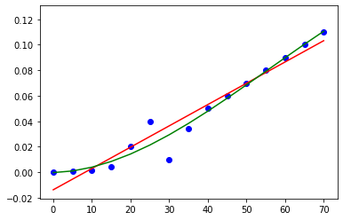

```python
poly = PolynomialFeatures(degree=3)
X_poly = poly.fit_transform(X)
poly.fit(X_poly, y)
lin2 = LinearRegression()
lin2.fit(X_poly, y)

plt.scatter(X, y, color = 'blue')

plt.plot(X, lin.predict(X), color = 'red')
plt.plot(X, lin2.predict(poly.fit_transform(X)), color = 'green')
plt.show()
```

```python
X_poly # 1, x , x^2 , x^3
```

```
array([[1.00000e+00, 0.00000e+00, 0.00000e+00, 0.00000e+00],
       [1.00000e+00, 5.00000e+00, 2.50000e+01, 1.25000e+02],
       [1.00000e+00, 1.00000e+01, 1.00000e+02, 1.00000e+03],
       [1.00000e+00, 1.50000e+01, 2.25000e+02, 3.37500e+03],
       [1.00000e+00, 2.00000e+01, 4.00000e+02, 8.00000e+03],
       [1.00000e+00, 2.50000e+01, 6.25000e+02, 1.56250e+04],
       [1.00000e+00, 3.00000e+01, 9.00000e+02, 2.70000e+04],
       [1.00000e+00, 3.50000e+01, 1.22500e+03, 4.28750e+04],
       [1.00000e+00, 4.00000e+01, 1.60000e+03, 6.40000e+04],
       [1.00000e+00, 4.50000e+01, 2.02500e+03, 9.11250e+04],
       [1.00000e+00, 5.00000e+01, 2.50000e+03, 1.25000e+05],
       [1.00000e+00, 5.50000e+01, 3.02500e+03, 1.66375e+05],
       [1.00000e+00, 6.00000e+01, 3.60000e+03, 2.16000e+05],
       [1.00000e+00, 6.50000e+01, 4.22500e+03, 2.74625e+05],
       [1.00000e+00, 7.00000e+01, 4.90000e+03, 3.43000e+05]])
```

Παρατηρούμε πως αυξάνεται και άλλο η προσαρμογή της καμπύλης στα δεδομένα μας.

#### *degree* = 4

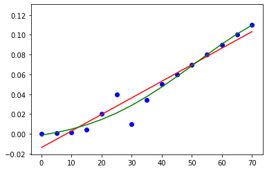

```python
poly = PolynomialFeatures(degree=4)
X_poly = poly.fit_transform(X)
poly.fit(X_poly, y)
lin2 = LinearRegression()
lin2.fit(X_poly, y)

plt.scatter(X, y, color = 'blue')

plt.plot(X, lin.predict(X), color = 'red')
plt.plot(X, lin2.predict(poly.fit_transform(X)), color = 'green')
plt.show()
```

Ομοίως και εδώ, με την αύξηση του βαθμού παίρνουμε ακόμα πιο ακριβής καμπύλη, η οποία περνάει πολύ κοντά η ακριβώς από τα δεδομένα μας.

#### *degree* = 5

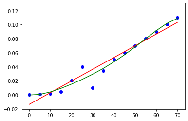

```python
poly = PolynomialFeatures(degree=5)
X_poly = poly.fit_transform(X)
poly.fit(X_poly, y)
lin2 = LinearRegression()
lin2.fit(X_poly, y)

plt.scatter(X, y, color = 'blue')

plt.plot(X, lin.predict(X), color = 'red')
plt.plot(X, lin2.predict(poly.fit_transform(X)), color = 'green')
plt.show()
```

Όμοια με πριν...

#### *degree* = 8

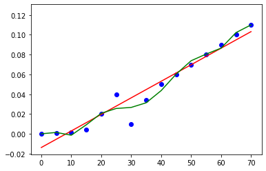

```python
poly = PolynomialFeatures(degree=8)
X_poly = poly.fit_transform(X)
poly.fit(X_poly, y)
lin2 = LinearRegression()
lin2.fit(X_poly, y)

plt.scatter(X, y, color = 'blue')

plt.plot(X, lin.predict(X), color = 'red')
plt.plot(X, lin2.predict(poly.fit_transform(X)), color = 'green')
plt.show()
```

Σε αυτό το σημείο αρχίζει το φαινόμενο overfitting και παρατηρούμε πως πλέον η καμπύλη προσπαθεί να περάσει ακριβώς από τα δεδομένα μας.

#### *degree* = 10

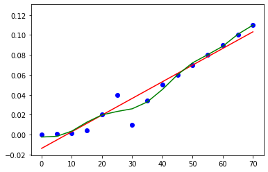

```python
poly = PolynomialFeatures(degree=10)
X_poly = poly.fit_transform(X)
poly.fit(X_poly, y)
lin2 = LinearRegression()
lin2.fit(X_poly, y)

plt.scatter(X, y, color = 'blue')

plt.plot(X, lin.predict(X), color = 'red')
plt.plot(X, lin2.predict(poly.fit_transform(X)), color = 'green')
plt.show()
```

#### *degree* = 12

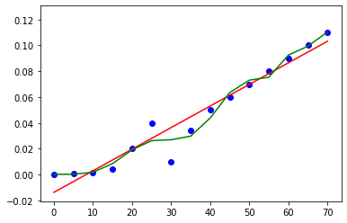

```python
poly = PolynomialFeatures(degree=12)
X_poly = poly.fit_transform(X)
poly.fit(X_poly, y)
lin2 = LinearRegression()
lin2.fit(X_poly, y)

plt.scatter(X, y, color = 'blue')

plt.plot(X, lin.predict(X), color = 'red')
plt.plot(X, lin2.predict(poly.fit_transform(X)), color = 'green')
plt.show()
```

Παρατηρούμε ότι πλέον προσαρμόζουμε θόρυβο στο μοντέλο μας και δεν υπάρχει γενίκευση.

#### *degree* = 15

```python
poly = PolynomialFeatures(degree=15)
X_poly = poly.fit_transform(X)
poly.fit(X_poly, y)
lin2 = LinearRegression()
lin2.fit(X_poly, y)

plt.scatter(X, y, color = 'blue')

plt.plot(X, lin.predict(X), color = 'red')
plt.plot(X, lin2.predict(poly.fit_transform(X)), color = 'green')
plt.show()
```

```
---------------------------------------------------------------------------
KeyboardInterrupt                         Traceback (most recent call last)
<ipython-input-13-d7637729cd72> in <module>
      1 poly = PolynomialFeatures(degree=15)
      2 X_poly = poly.fit_transform(X)
----> 3 poly.fit(X_poly, y)
      4 lin2 = LinearRegression()
      5 lin2.fit(X_poly, y)

~/anaconda3/lib/python3.7/site-packages/sklearn/preprocessing/data.py in fit(self, X, y)
   1468                                           self.include_bias)
   1469         self.n_input_features_ = n_features
-> 1470         self.n_output_features_ = sum(1 for _ in combinations)
   1471         return self
   1472

~/anaconda3/lib/python3.7/site-packages/sklearn/preprocessing/data.py in <genexpr>(.0)
   1468                                           self.include_bias)
   1469         self.n_input_features_ = n_features
-> 1470         self.n_output_features_ = sum(1 for _ in combinations)
   1471         return self
   1472

KeyboardInterrupt:
```

Αδυνατεί να τρέξει καθώς έχουμε 15 δείγματα και 15 χαρακτηριστικά + 1 το bias.

### *Ερώτημα 2*

Σας παρέχεται, επίσης, το αρχείο *data2b.csv*</i>, το οποίο είναι το αρχείο *data2.csv* με μία παραπάνω εγγραφή, την *(9, 38, 0.3)*</i>. Να εκτελέσετε το παρακάτω πρόγραμμα για την τιμή της παραμέτρου *degree = 15*. Πόσο μεγάλη είναι η αλλαγή που παρατηρείτε στη μορφή της γραμμής παλινδρόμησης σε σχέση με την αντίστοιχη περίπτωση του ερωτήματος 1; Τι συμπέρασμα μπορείτε να βγάλετε για τον αλγόριθμο *polynomial regression*;

Σημείωση: νομίζω πως έχει γίνει λάθος και η νέα εγγραφή είναι το 9,38,0.3

[output not shown]

[figure not shown]

```python
datas = pd.read_csv('data2b.csv')
print(datas)

X = datas.iloxc[:, 1:2].values
y = datas.iloc[:, 2].values

lin = LinearRegression()
lin.fit(X, y)

poly = PolynomialFeatures(degree=15)
X_poly = poly.fit_transform(X)
poly.fit(X_poly, y)
lin2 = LinearRegression()
lin2.fit(X_poly, y)

plt.scatter(X, y, color = 'blue')

plt.plot(X, lin.predict(X), color = 'red')
plt.plot(X, lin2.predict(poly.fit_transform(X)), color = 'green')
plt.show()
```

Με την είσοδο ενός στοιχείου το οποίο έχει μια αρκετά μεγαλύτερη τιμή από τα άλλα δείγματα πλέον μπορούμε να τρέξουμε το κομμάτι κώδικα για πολυώνυμο βαθμού 15.

Παρατηρούμε, πως γενικά η καμπύλη περνάει ακριβώς από τα δεδομένα μας μέχρι τις τιμές για χ από 30 ως 45 όπου αυτό το σημείο επηρεάζεται από τη νέα εγγραφή, η οποία έχει πολύ μεγάλη τιμή και επηρεάζει την ευθεία να περάσει από αυτό. (σημείο επιρροής.)

### Γενικά, παρατηρούμε πως με την αύξηση του βαθμού του πολυωνύμου η ευθεία προσαρμόζεται όλο και περισσότερο στα δεδομένα με αποτέλεσμα να τείνει σε overfit και να μη γενικεύει που είναι το ζητούμενο.